# Do skin releases coincide with favorable champion treatment?

Patch-note attention, balance direction, and player response

## The question

League of Legends players sometimes suspect that champions are buffed around a skin release. There are at least three different claims hidden inside that suspicion:

1. Champions receiving a skin may be more likely to appear in the patch notes.
2. When they do appear, their changes may be more likely to be buffs than nerfs.
3. Whatever happens in the patch notes may translate into better in-game performance.

Those claims require different comparisons. This article follows them in order, moving from balance-team attention to the direction of classified changes and finally to observed win, pick, and ban rates.

The result is more nuanced than “skins cause buffs.” Champions near a skin release do receive more patch-note attention. However, the evidence does not show a reliable shift toward buffs or an increase in win rate. What changes most clearly after a release is player attention: pick and ban rates rise.

## Analysis design

The current analysis uses the following parameters. These are the only non-SQL implementation details shown in the article; the R code that constructs tables, tests, and figures is hidden from the rendered output.

```r
skin_release_cutoff_year <- 2014L
skin_patch_window_days <- 42L
champion_release_window_days <- 60L
rework_window_days <- 60L
pre_performance_days <- 28L
post_performance_days <- 14L
```

A skin is eligible when it was released in 2014 or later and is not within 60 days of either the champion’s original release or a classified rework. The cutoff aligns the analysis with the start of the stored League of Graphs performance histories in March 2014. Patch-note windows extend 42 days in both directions from an eligible skin release. Performance changes are measured as the interpolated value 14 days after an anchor minus the value 28 days before it. All rate changes are reported in percentage points.

The unit of the patch-note analysis is a champion–patch opportunity: every champion available on a patch date either appears in that patch’s notes or does not. The unit of the balance analysis is one aggregate classification for a champion in a patch. The performance analysis compares eligible skin releases with champion–patch dates outside every eligible skin-release window.

### From all skins to the analysis cohort

Skin-release cohort construction.

| Cohort | Skin releases |
| --- | --- |
| All dated skin releases | 1,947 |
| Skin releases from 2014 | 1,455 |
| Skin releases from 2014 outside 60-day champion-release/rework windows | 1,377 |

The cutoff removes the unusually dense early years, while the release/rework exclusion avoids treating the launch of a new champion or a major redesign as an ordinary skin event.

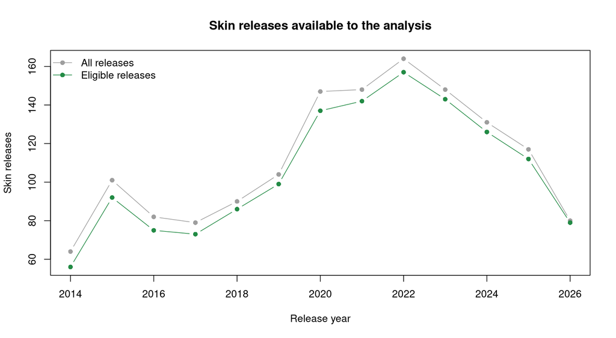

Total and eligible skin releases by year after the analysis cutoff.

Skin releases are not evenly distributed across champions. The champions with the largest catalogues are also a useful warning about confounding: commercially prominent champions recur throughout the data.

Champions with the most dated non-base skin releases (top 20 by overall count).

| Champion ID | Champion | All releases | Releases since cutoff |
| --- | --- | --- | --- |
| 21 | Miss Fortune | 23 | 17 |
| 84 | Akali | 22 | 15 |
| 99 | Lux | 22 | 17 |
| 103 | Ahri | 21 | 17 |
| 81 | Ezreal | 21 | 15 |
| 22 | Ashe | 20 | 15 |
| 51 | Caitlyn | 20 | 15 |
| 1 | Annie | 19 | 11 |
| 55 | Katarina | 19 | 12 |
| 64 | Lee Sin | 19 | 14 |
| 15 | Sivir | 19 | 13 |
| 67 | Vayne | 19 | 15 |
| 53 | Blitzcrank | 18 | 11 |
| 10 | Kayle | 18 | 11 |
| 89 | Leona | 18 | 14 |
| 11 | Master Yi | 18 | 13 |
| 16 | Soraka | 18 | 15 |
| 157 | Yasuo | 18 | 17 |
| 86 | Garen | 17 | 11 |
| 24 | Jax | 17 | 10 |

### Pricing coverage

Exact, published RP price bands provide a transparent first-pass skin-tier variable. The mapping uses 520 RP as Basic, 750 as Deluxe, 975 as Standard, 1,350 as Epic, 1,820 as Legendary, and 2,775/3,250 as Ultimate; the small legacy 390 RP group is retained separately. Costs outside those exact bands, including missing values and special currency values, are not forced into an RP tier. These band definitions follow the [League Wiki’s pricing table](https://leagueoflegends.fandom.com/wiki/Champion_skin#Pricing).

Eligible skin releases by recognized RP price band.

| Price category | Eligible skin releases | Champions |
| --- | --- | --- |
| Basic (520 RP) | 1 | 1 |
| Deluxe (750 RP) | 80 | 65 |
| Standard (975 RP) | 73 | 56 |
| Epic (1350 RP) | 895 | 170 |
| Legendary (1820 RP) | 103 | 65 |
| Ultimate (2775/3250 RP) | 4 | 4 |
| Non-standard or missing price | 221 | 117 |

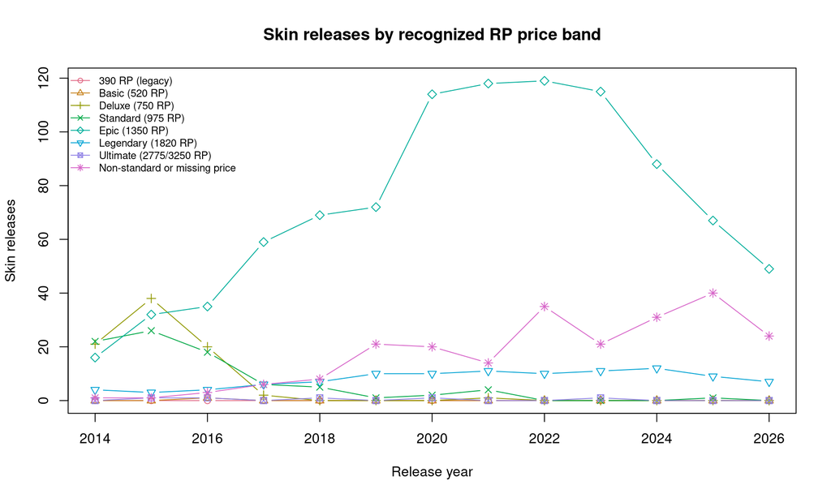

Dated skin releases from the analysis cutoff onward, by exact RP price band and release year.

This makes a tier-stratified analysis feasible, but not yet sufficient for a causal claim: price is also related to release era, availability, and whether the skin is part of a major event. Those factors should be kept explicit when comparing tiers.

## Finding 1: skin releases coincide with more patch-note attention

Champions within a skin-release window appeared in the patch notes more often than other available champions. The overall rates are shown below; the annual plot matters because both the champion roster and Riot’s patch philosophy changed over time.

Patch-note appearances among champion–patch opportunities.

| Skin-release window | Opportunities | Appearances | Appearance rate |
| --- | --- | --- | --- |
| No nearby skin release | 39,298 | 7,601 | 19.3% |
| Within skin-release window | 7,860 | 1,798 | 22.9% |

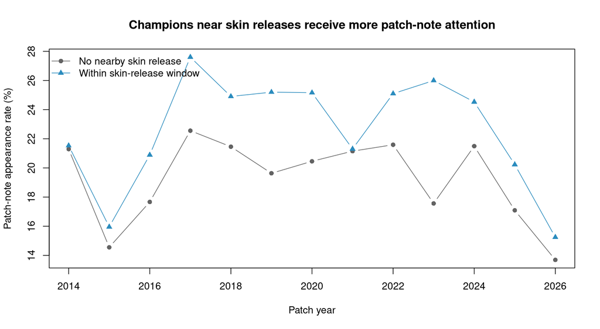

Annual patch-note appearance rates for champions within and outside eligible skin-release windows.

A Mantel–Haenszel test stratified by patch year estimates a common odds ratio of 1.24 (95% CI 1.17–1.31, *p* = 7.56e-13). In other words, after accounting for year, the odds of appearing in the patch notes are about 24% higher within a skin-release window.

This is strong evidence of an association, but it is not evidence that a skin release causes balance attention. Champions chosen for skins may already be more popular, more actively maintained, or otherwise more likely to need a change.

## Finding 2: the extra attention is not clearly more favorable

More patch-note appearances do not necessarily mean more buffs. Among champion–patch classifications labeled as a buff or nerf, the observed buff-to-nerf ratio is somewhat higher near skin releases.

Buff and nerf classifications from the cutoff year onward.

| Skin-release window | Buffs | Nerfs | Buff-to-nerf ratio | Buff share |
| --- | --- | --- | --- | --- |
| No nearby skin release | 3,098 | 2,035 | 1.52 | 60.4% |
| Within skin-release window | 660 | 393 | 1.68 | 62.7% |

The year-stratified Mantel–Haenszel test estimates a buff odds ratio of 1.10 (95% CI 0.96–1.26, *p* = 0.201). The point estimate leans in the suspected direction, but the confidence interval includes no difference. The data therefore do not provide convincing evidence that the additional attention near skin releases is systematically more buff-oriented.

## Finding 3: win rate is stable, while pick and ban rates rise

For every performance observation, the delta is the interpolated rate 14 days after the anchor minus the rate 28 days before it. Positive values represent an increase. The broad comparison population consists of champion–patch dates outside eligible skin-release windows.

Mean performance changes from 28 days before to 14 days after the anchor.

| Metric | Group | Observations | Mean delta (pp) | Median delta (pp) |
| --- | --- | --- | --- | --- |
| Ban rate | General population | 38,441 | -0.119 | -0.038 |
| Ban rate | Skin release | 1,366 | 0.527 | 0.055 |
| Pick rate | General population | 38,441 | -0.091 | -0.112 |
| Pick rate | Skin release | 1,366 | 1.041 | 0.556 |
| Win rate | General population | 38,441 | 0.003 | -0.017 |
| Win rate | Skin release | 1,366 | 0.022 | -0.010 |

The yearly distributions tell the same broad story. Win-rate changes cluster around zero for both groups. Pick- and ban-rate changes are more dispersed, but skin releases tend to sit higher than the comparison population. Outlying points are suppressed in the figures so that the central distributions remain legible; they remain in every calculation.

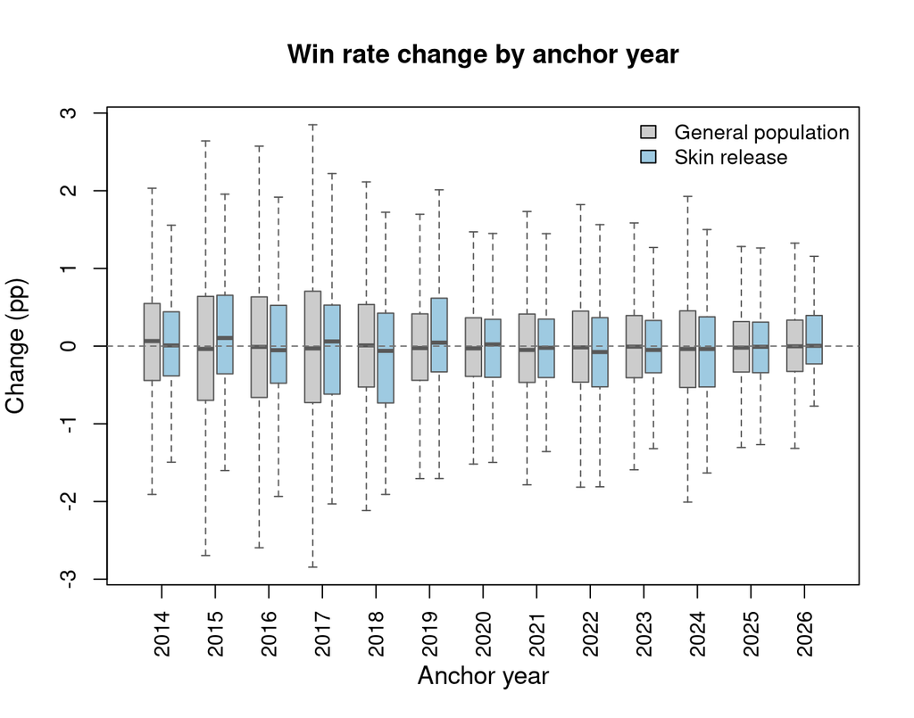

Win-rate changes from 28 days before to 14 days after the anchor, by year.

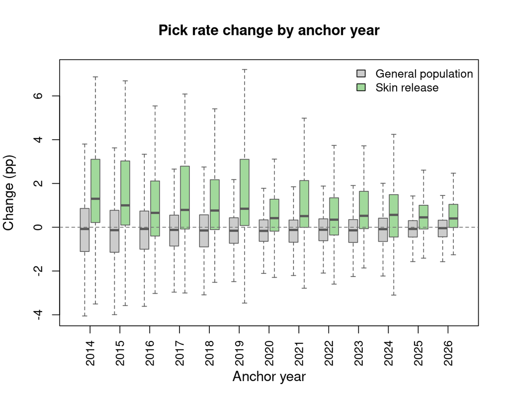

Pick-rate changes from 28 days before to 14 days after the anchor, by year.

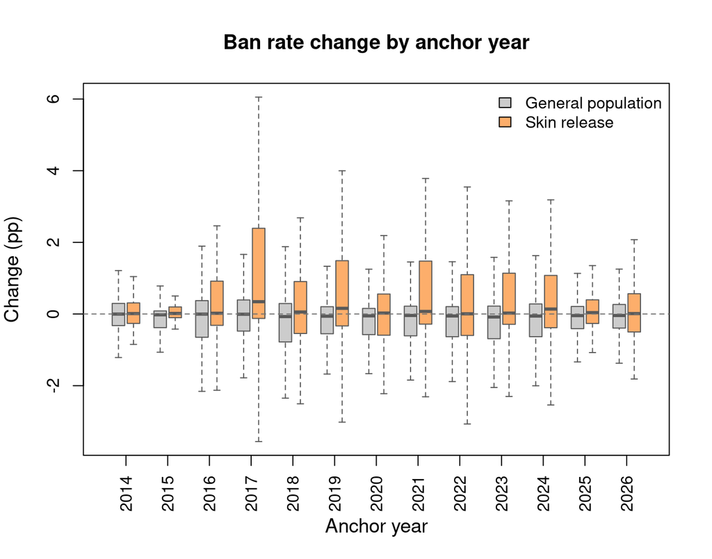

Ban-rate changes from 28 days before to 14 days after the anchor, by year.

The performance histories begin on 11 March 2014. Consequently, very early 2014 releases without both the required 28-day pre-release and 14-day post-release observations are excluded automatically rather than extrapolated.

Across all years, eligible skin releases have a mean win-rate delta of +0.022 percentage points, compared with +0.003 in the broad comparison population. The corresponding mean deltas are +1.04 versus -0.09 percentage points for pick rate and +0.53 versus -0.12 for ban rate.

The pick- and ban-rate increases are consistent with players paying more attention to a champion after a cosmetic release. They do not, by themselves, distinguish a skin effect from promotion, concurrent game changes, or selection of champions whose popularity was already moving.

### Same-champion controls and statistical tests

The confirmatory comparison matches every usable skin release to a different patch date for the same champion. A control’s complete measurement interval is prohibited from overlapping another skin-release window. This holds fixed the champion without adding hundreds of sparsely observed champion indicator coefficients.

Estimated skin-release effect on the win-rate delta under same-champion control models.

| Model | Estimated effect (pp) | 95% CI | p-value |
| --- | --- | --- | --- |
| Same-champion controls, adjusted for year | 0.030 | -0.043 to 0.104 | 0.419 |
| Plus pre-window popularity | 0.025 | -0.048 to 0.098 | 0.499 |

For all three outcomes, the table below adds a paired *t*-test. The null hypothesis is that a release’s change and its matched same-champion control’s change have a mean difference of zero. Unlike the win-rate regression above, these tests do not adjust for pre-window popularity; they are a direct paired comparison of the matched deltas.

Paired tests of skin-release deltas versus same-champion control deltas.

| Metric | Matched pairs | Mean difference (pp) | 95% CI | p-value |
| --- | --- | --- | --- | --- |
| Win rate | 1,356 | 0.030 | -0.047 to 0.107 | 0.441 |
| Pick rate | 1,356 | 1.204 | 1.026 to 1.383 | 1.15e-37 |
| Ban rate | 1,356 | 0.604 | 0.281 to 0.927 | 2.57e-04 |

The paired test and the year-adjusted win-rate model agree: there is no evidence of a systematic win-rate increase. In contrast, pick and ban rates increase significantly relative to matched same-champion control dates.

The following models apply the same calendar-year and pre-window-popularity adjustment used for win rate to pick- and ban-rate deltas. For pick rate, the popularity covariate is also the pre-window pick rate, so it serves as a baseline adjustment as well as a measure of prior popularity.

Estimated skin-release effects on pick- and ban-rate deltas under same-champion control models.

| Metric | Adjustment | Observations | Estimated effect (pp) | 95% CI | p-value |
| --- | --- | --- | --- | --- | --- |
| Pick rate | Adjusted for calendar year | 2,712 | 1.204 | 1.040 to 1.369 | 6e-45 |
| Pick rate | Adjusted for calendar year and pre-window popularity | 2,712 | 1.195 | 1.031 to 1.359 | 1.14e-44 |
| Ban rate | Adjusted for calendar year | 2,712 | 0.604 | 0.310 to 0.898 | 5.83e-05 |
| Ban rate | Adjusted for calendar year and pre-window popularity | 2,712 | 0.600 | 0.306 to 0.894 | 6.49e-05 |

### Does the association differ by skin type or Prestige status?

This exploratory extension gives each matched control the price group and Prestige status of its paired skin release. Exact RP bands are retained in the descriptive table above, but the effect models combine the sparse bands into lower-priced RP tiers (390–975 RP), Epic (1,350 RP), premium RP tiers (1,820 RP or more), and non-standard or missing prices. A skin is classed as Prestige when its display name contains the word “Prestige”; this is a reproducible name inference, not a dedicated source-data field.

Usable same-champion skin-release pairs by modelled price group and inferred Prestige status.

| Price group | Prestige status | Usable releases | Champions |
| --- | --- | --- | --- |
| Epic (1350 RP) | Non-Prestige | 888 | 170 |
| Lower-priced RP tiers (390-975 RP) | Non-Prestige | 142 | 92 |
| Premium RP tiers (1820+ RP) | Non-Prestige | 105 | 65 |
| Non-standard or missing price | Non-Prestige | 110 | 82 |
| Non-standard or missing price | Prestige | 111 | 72 |

The sparse structure is important: all inferred Prestige releases in the usable cohort have non-standard or missing RP prices. Therefore, price-group and Prestige results are estimated in separate models; neither should be interpreted as holding the other characteristic fixed.

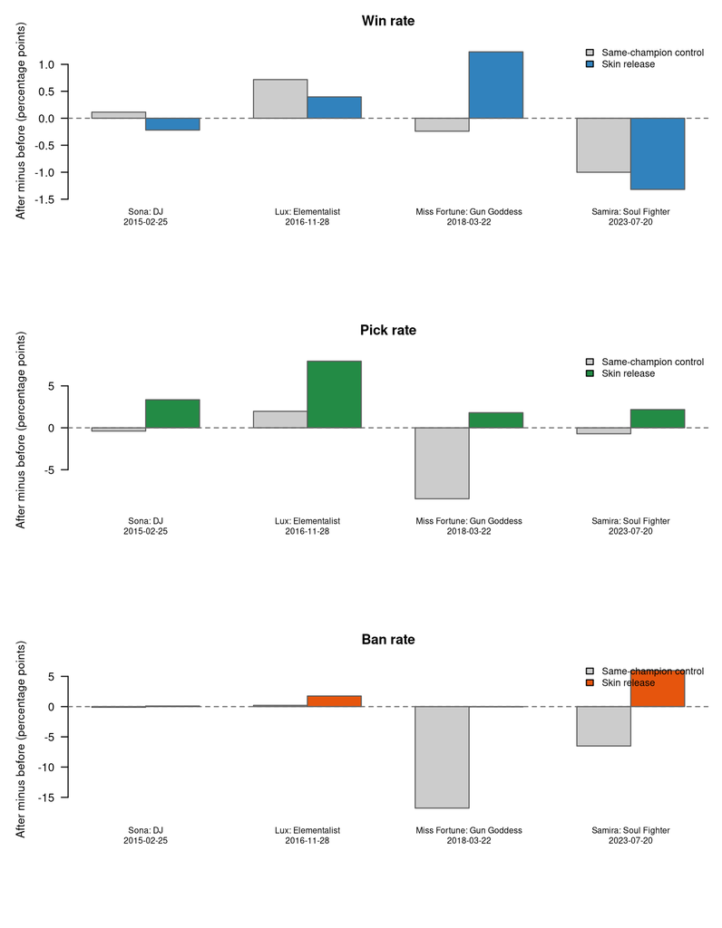

Individual rate changes around usable Ultimate-skin releases and their matched same-champion controls. Each bar is the interpolated value 14 days after its anchor minus the value 28 days before it.

Global tests of whether the matched skin-release effect differs by price group or inferred Prestige status.

| Metric | Characteristic | Usable releases | Interaction p-value |
| --- | --- | --- | --- |
| Ban rate | Prestige status | 1,356 | 0.659 |
| Pick rate | Prestige status | 1,356 | 0.430 |
| Win rate | Prestige status | 1,356 | 0.892 |
| Ban rate | Price group | 1,356 | 4.89e-04 |
| Pick rate | Price group | 1,356 | 2.13e-07 |
| Win rate | Price group | 1,356 | 0.418 |

Adjusted same-champion skin-release effects within each price group and inferred Prestige status.

| Metric | Characteristic | Group | Usable releases | Estimated effect (pp) | 95% CI | p-value |
| --- | --- | --- | --- | --- | --- | --- |
| Ban rate | Prestige status | Non-Prestige | 1,245 | 0.580 | 0.273 to 0.887 | 2.17e-04 |
| Ban rate | Prestige status | Prestige | 111 | 0.822 | -0.206 to 1.850 | 0.117 |
| Pick rate | Prestige status | Non-Prestige | 1,245 | 1.175 | 1.004 to 1.346 | 5.45e-40 |
| Pick rate | Prestige status | Prestige | 111 | 1.416 | 0.843 to 1.989 | 1.35e-06 |
| Win rate | Prestige status | Non-Prestige | 1,245 | 0.027 | -0.049 to 0.103 | 0.492 |
| Win rate | Prestige status | Prestige | 111 | 0.008 | -0.247 to 0.263 | 0.949 |
| Ban rate | Price group | Epic (1350 RP) | 888 | 0.349 | -0.014 to 0.711 | 0.059 |
| Ban rate | Price group | Lower-priced RP tiers (390-975 RP) | 142 | 0.307 | -0.600 to 1.213 | 0.507 |
| Ban rate | Price group | Non-standard or missing price | 221 | 0.792 | 0.065 to 1.518 | 0.033 |
| Ban rate | Price group | Premium RP tiers (1820+ RP) | 105 | 2.703 | 1.649 to 3.756 | 5.23e-07 |
| Pick rate | Price group | Epic (1350 RP) | 888 | 0.960 | 0.760 to 1.160 | 1.04e-20 |
| Pick rate | Price group | Lower-priced RP tiers (390-975 RP) | 142 | 1.476 | 0.976 to 1.976 | 8.15e-09 |
| Pick rate | Price group | Non-standard or missing price | 221 | 1.204 | 0.803 to 1.605 | 4.43e-09 |
| Pick rate | Price group | Premium RP tiers (1820+ RP) | 105 | 2.752 | 2.171 to 3.334 | 3.52e-20 |
| Win rate | Price group | Epic (1350 RP) | 888 | 0.058 | -0.032 to 0.148 | 0.205 |
| Win rate | Price group | Lower-priced RP tiers (390-975 RP) | 142 | -0.070 | -0.295 to 0.155 | 0.544 |
| Win rate | Price group | Non-standard or missing price | 221 | -0.081 | -0.261 to 0.099 | 0.379 |
| Win rate | Price group | Premium RP tiers (1820+ RP) | 105 | 0.099 | -0.163 to 0.360 | 0.459 |

There is no evidence that either price group or inferred Prestige status changes the win-rate result (interaction *p* = 0.418 and 0.892, respectively). Price groups do modify the post-release attention pattern: the global interaction tests are *p* = 2.13e-07 for pick rate and *p* = 4.89e-04 for ban rate. The premium group has the largest estimated increases (+2.752 percentage points in pick rate and +2.703 in ban rate), whereas Epic releases show +0.960 and +0.349, respectively. This is an association, not evidence that a more expensive skin independently causes player attention: price, special currency, Prestige status, event promotion, and the selection of champions are intertwined. The inferred Prestige interactions themselves are not statistically detectable for win, pick, or ban rate.

The year-adjusted win-rate estimate remains close to zero, and adding pre-window popularity does not materially change it. Pre-window popularity itself is negatively associated with the subsequent win-rate delta in this model, but that coefficient is observational and may reflect mean reversion or balance responses to popular champions. It does not support the idea that popularity-driven skin economics produces a detectable short-term win-rate increase.

## What the evidence currently says

The clearest result is about **attention**, not favorable treatment. Champions close to a skin release appear in patch notes more often. Once attention is observed, however, the buff/nerf mix is not convincingly different, and neither the broad nor the same-champion comparison detects an average win-rate increase. Pick and ban rates rise after skin releases relative to same-champion control dates, suggesting that cosmetic launches coincide with increased player interest even when win rate stays stable.

This distinction matters. “The balance team looks at champions receiving skins” is compatible with the data. “Champions are made stronger to sell skins” is not established by the current results.

## What would strengthen the article next

The following additions would contribute more than another descriptive chart:

1. **An event-study figure.** Plot weekly win, pick, and ban-rate differences from several weeks before to several weeks after release, using same-champion placebo dates. This would reveal anticipation, short-lived launch spikes, persistence, and mean reversion that a two-point delta cannot show.
2. **A repeated-measures model for patch-note appearances.** The Mantel–Haenszel test controls for year but treats recurring champion–patch opportunities approximately as independent. A mixed-effects model or clustered standard errors by champion and patch would better reflect the data structure. Pre-window popularity, champion age, and release cadence are natural covariates.
3. **Placebo and permutation checks.** Assign matched pseudo-release dates to the same champions and repeat the complete pipeline. This would show how often effects as large as the observed ones arise from champion selection and calendar structure alone.
4. **Skin-level heterogeneity.** The recognized RP price-band mapping above is a reproducible first split. Prestige status is currently inferred from the display name; a dedicated source field and event-promotion field would make the price/Prestige comparison substantially more credible. Availability, loot eligibility, skin-set membership, simultaneous skin-line launches, and multiple skins for one champion on the same date are useful additional release-level features.

Of these, the event study plus placebo dates would be the most informative next step: it would turn the current before/after snapshot into a time-resolved test while keeping the comparison within champion.

## Limitations

- This is an observational analysis. Skin selection, balance attention, champion popularity, and marketing are jointly determined.
- The same champions and patches recur, so simple tests can understate uncertainty unless dependence is modeled.
- Broad performance controls are anchored on patch dates, whereas treatment observations are anchored on exact skin release dates.
- Linear interpolation cannot recover short-lived movements between observations and does not extrapolate beyond a champion series’ observed range.
- The classifier reduces all changes for one champion in one patch to a single label. That is the desired unit here, but complex mixed changes inevitably lose detail.
- The latest calendar year may be incomplete and should not be interpreted as a full-year total.

## Data queries

The analytical transformations are hidden, but the SQL that defines the source data remains visible for auditability.

### Dated non-base skins

```sql
SELECT
  champions.game_id AS champion_id,
  champions.name AS champion_name,
  skins.wiki_skin_id AS skin_id,
  skins.display_name AS skin_name,
  skins.release_date AS skin_release_date,
  skins.cost AS skin_cost,
  base_skin.release_date AS champion_release_date
FROM skins
JOIN champions ON champions.id = skins.champion_id
JOIN skins AS base_skin
  ON base_skin.champion_id = champions.id
 AND base_skin.is_base = 1
WHERE skins.is_base = 0
  AND skins.release_date IS NOT NULL
  AND skins.availability <> 'Canceled'
ORDER BY skins.release_date, champions.name, skins.wiki_skin_id;
```

### Performance histories

```sql
SELECT
  champions.game_id AS champion_id,
  graph_series.metric,
  graph_points.observed_at_ms,
  graph_points.value
FROM graph_points
JOIN graph_series ON graph_series.id = graph_points.graph_series_id
JOIN champions ON champions.id = graph_series.champion_id
WHERE graph_series.metric IN ('win_rate', 'popularity', 'ban_rate')
ORDER BY champions.game_id, graph_series.metric, graph_points.observed_at_ms;
```

### Aggregate champion–patch classifications

```sql
SELECT
  champions.game_id AS champion_id,
  patch_classifications.patch_id,
  patches.release_date AS patch_release_date,
  patch_classifications.label AS classification_label,
  patch_classifications.confidence
FROM patch_classifications
JOIN champions ON champions.id = patch_classifications.champion_id
JOIN patches ON patches.patch_id = patch_classifications.patch_id
WHERE patch_classifications.label IN ('buff', 'nerf', 'rework');
```

### Champion and patch calendars

```sql
SELECT
  champions.game_id AS champion_id,
  champions.name AS champion_name,
  base_skin.release_date AS champion_release_date
FROM champions
JOIN skins AS base_skin
  ON base_skin.champion_id = champions.id
 AND base_skin.is_base = 1
WHERE base_skin.release_date IS NOT NULL;

SELECT patch_id, release_date AS patch_release_date
FROM patches
WHERE release_date IS NOT NULL
ORDER BY release_date, patch_id;
```

### Patch-note appearances

```sql
SELECT DISTINCT
  champions.game_id AS champion_id,
  patch_events.patch_id
FROM patch_events
JOIN champions ON champions.id = patch_events.champion_id
JOIN patches ON patches.patch_id = patch_events.patch_id
WHERE patches.release_date IS NOT NULL;
```